# Visualización y exploración de datos

# Agrupación de datos

Podemos mapear una variable categórica a un estético como el color, el tipo de línea o la forma del punto, para representar datos de diferentes categorías separadamente. A continuación usamos el color para resumir la relación entre frecuencia alélica y error estándar del estadístico, según el número de individuos utilizados.

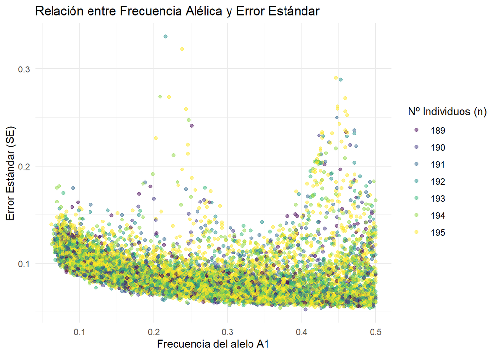

```r
ggplot(gwas, aes(x = A1_FREQ, y = SE, color = as.factor(OBS_CT))) +
  geom_point(alpha = 0.5) +
  scale_color_viridis_d() + # Una paleta de colores legible y profesional
  labs(title = "Relación entre Frecuencia Alélica y Error Estándar",
       x = "Frecuencia del alelo A1",
       y = "Error Estándar (SE)",
       color = "Nº Individuos (n)") +
  theme_minimal()
```

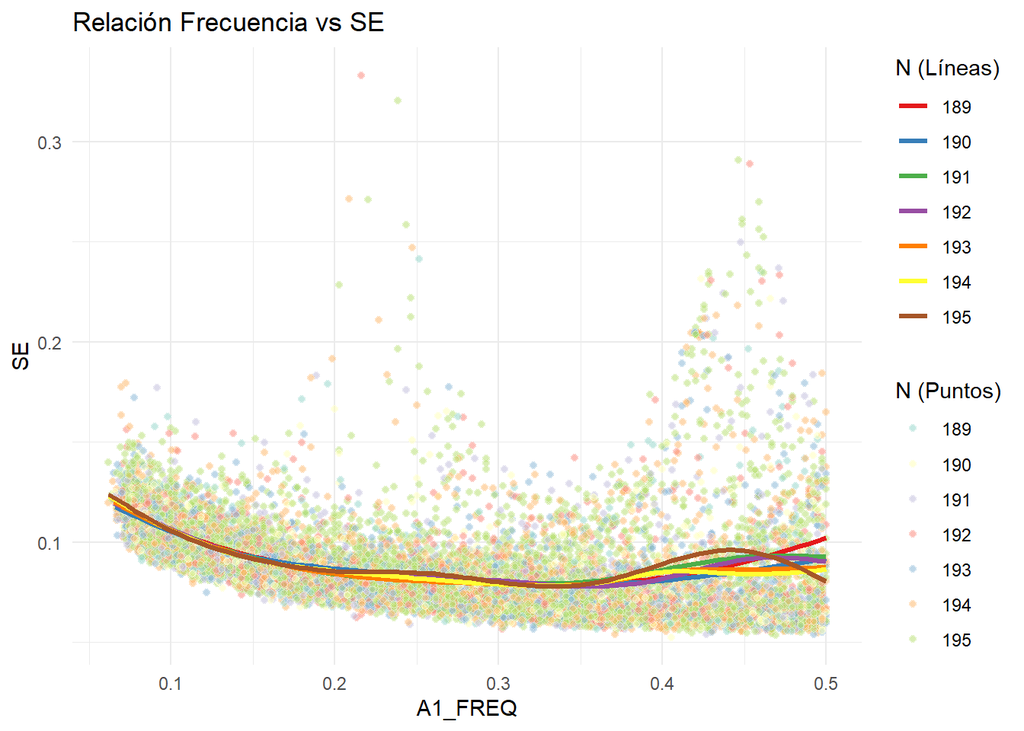

```r
ggplot(data = gwas, mapping = aes(x = A1_FREQ, y = SE, group = factor(OBS_CT))) +
  # Usamos shape = 21 (círculo con borde y relleno)
  geom_point(aes(fill = factor(OBS_CT)), shape = 21, color = "white", alpha = 0.5) +
  geom_smooth(aes(color = factor(OBS_CT)), se = FALSE, linewidth = 1.2) +
  # Definimos las dos paletas
  scale_fill_brewer(palette = "Set3") +   # Paleta para los puntos
  scale_color_brewer(palette = "Set1") +  # Paleta para las líneas
  labs(title = "Relación Frecuencia vs SE",
       fill = "N (Puntos)",
       color = "N (Líneas)") +
  theme_minimal()
```

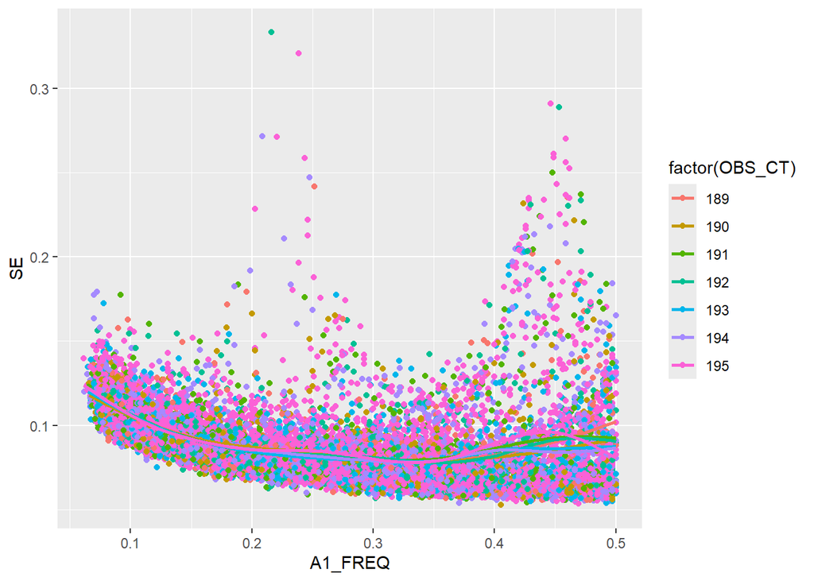

```r
ggplot(data = gwas,
       mapping = aes(x = A1_FREQ, y = SE)) +
   geom_point(mapping = aes(color = factor(OBS_CT)), se = FALSE) +
   geom_smooth(mapping = aes(color = factor(OBS_CT)), se = FALSE)
```

Otra forma de agrupar los datos es mediante las *facetas*:

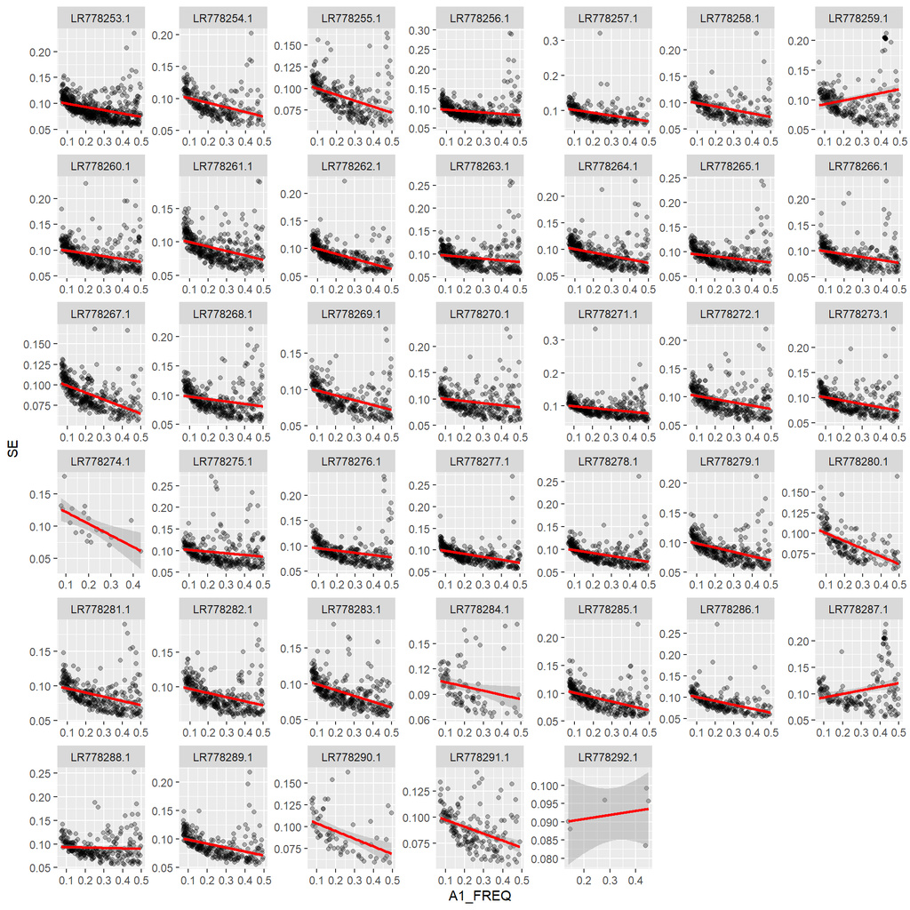

```r
ggplot(data = gwas,
       mapping = aes(x = A1_FREQ, y = SE)) +
   geom_point(alpha = 0.3) +
   geom_smooth(method = "lm", color = "red") +
   facet_wrap(~CHROM, scale = 'free')
```

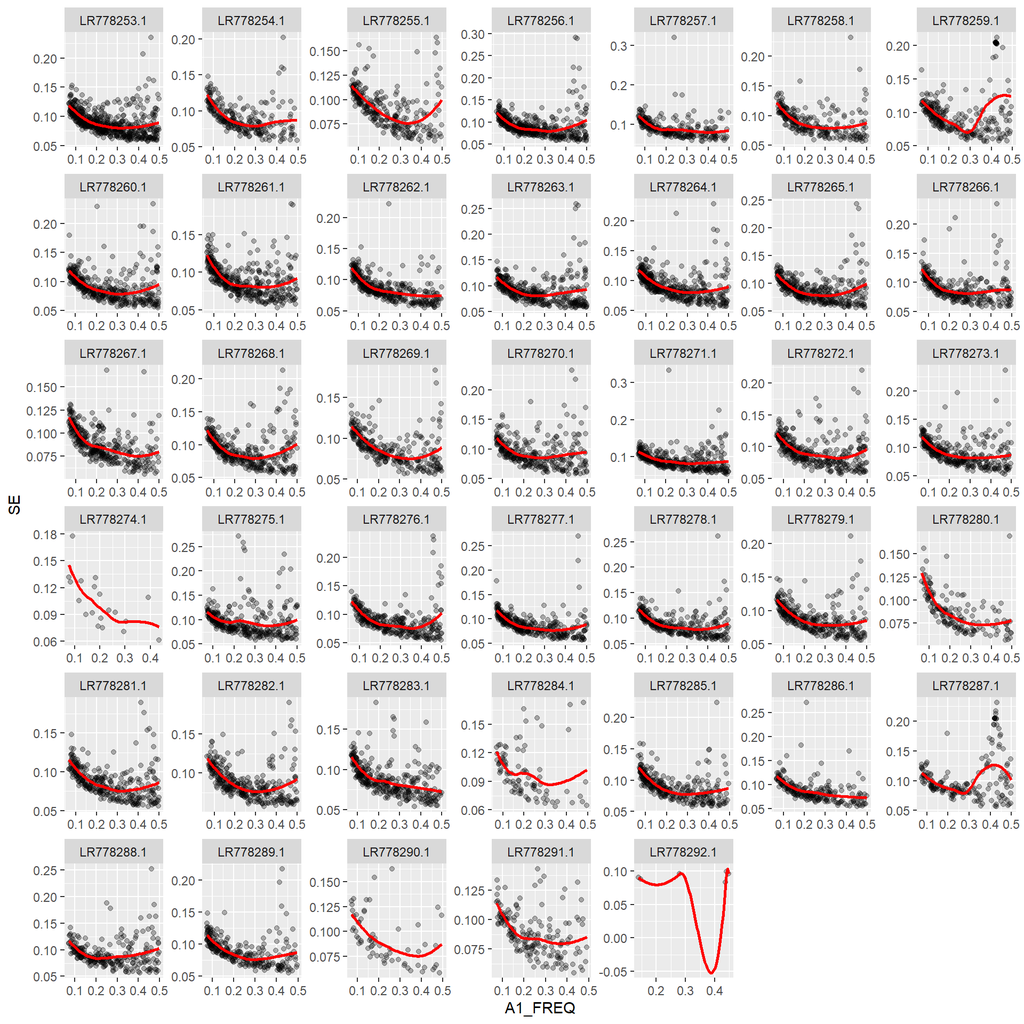

```r
ggplot(data = gwas,
       mapping = aes(x = A1_FREQ, y = SE)) +
   geom_point(alpha = 0.3) +
   geom_smooth(method = "loess", se = FALSE, color = "red") +
   facet_wrap(~CHROM, scale = 'free')
```

**NotaDesafíos**

1. Haz que no sólo las líneas, sino también los puntos tengan colores diferentes, que correspondan a los valores de OBS_CT, en la gráfica donde has usado `geom_smooth()`.

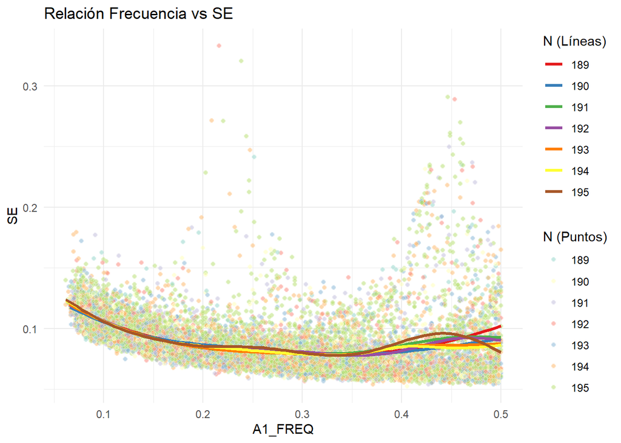

```r
ggplot(data = gwas, mapping = aes(x = A1_FREQ, y = SE, group = factor(OBS_CT))) +
  # Usamos shape = 21 (círculo con borde y relleno)
  geom_point(aes(fill = factor(OBS_CT)), shape = 21, color = "white", alpha = 0.5) +
  geom_smooth(aes(color = factor(OBS_CT)), se = FALSE, linewidth = 1.2) +
  # Definimos las dos paletas
  scale_fill_brewer(palette = "Set3") +   # Paleta para los puntos
  scale_color_brewer(palette = "Set1") +  # Paleta para las líneas
  labs(title = "Relación Frecuencia vs SE",
       fill = "N (Puntos)",
       color = "N (Líneas)") +
  theme_minimal()
```

2. Añade una línea suavizada (`geom_smooth()`) a cada cromosoma en el gráfico anterior.

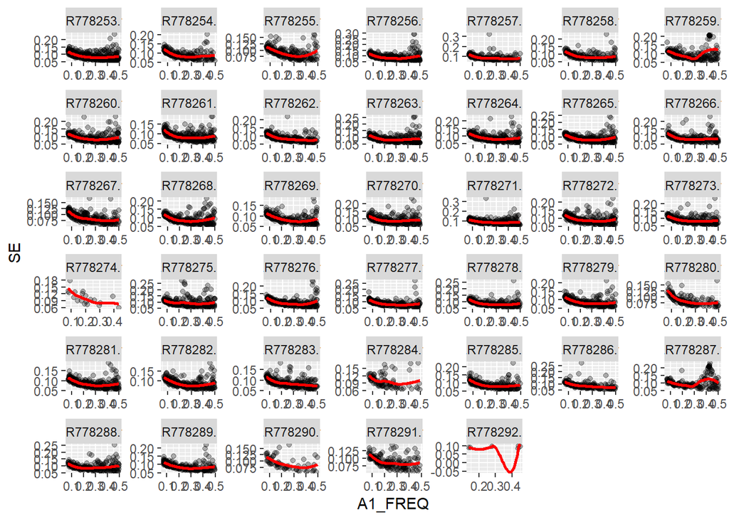

```r
ggplot(data = gwas, mapping = aes(x = A1_FREQ, y = SE)) +
   geom_point(alpha = 0.3) +
   geom_smooth(method = "loess", se = FALSE, color = "red") +
   facet_wrap(~CHROM, scale = 'free')
```

Puede usarse el método lm, que es para ajustar a la ecuación de una recta; pero también se puede usar el método loess que se ajusta a la forma de una curva.

3. ¿Cómo puedes deshacerte de los mensajes de `geom_smooth()`?

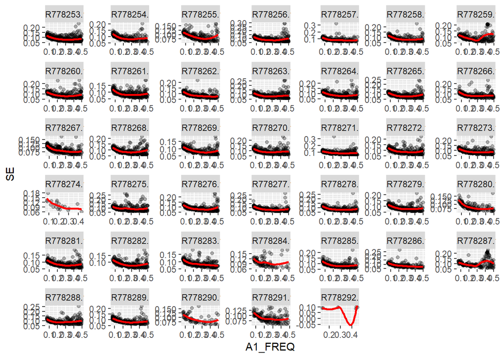

```r
ggplot(data = gwas, mapping = aes(x = A1_FREQ, y = SE)) +
   geom_point(alpha = 0.3) +
   geom_smooth(method = "loess", se = FALSE, color = "red") +
   facet_wrap(~CHROM, scale = 'free')
```

Añadiendo al principio dle bloque: {r, message = FALSE, warning = FALSE}.

4. ¿Para qué sirve la opción `scale = 'free'` en `facet_wrap()`?

Por defecto, cuando separas una gráfica en varios paneles con facet_wrap(), R obliga a que todas las ventanas tengan los mismos límites en los ejes X e Y. Al poner la opción scale = free, haces que los ejes de cada cromosoma se adapten solos a sus propios datos. Esto viene muy bien cuando un cromosoma tiene valores muy pequeños y otro muy grandes, porque así puedes ver bien el detalle de cada gráfico sin que se quede un montón de espacio en blanco.

Si en cualquier momento quiero guardar en el ordenador el resultado de un gráfico que acabo de generar, solo hay que escribir la función ggsave() en la consola o en mi script. Al ejecutarla, R cogerá automáticamente la última gráfica que haya pintado en la pantalla y la guardará como una imagen en la carpeta de tu proyecto.

# Agrupación de datos y estadísticos

Al examinar la relación entre el error estándar y el tamaño muestral, podemos tratar el tamaño muestral como variable categórica, porque tiene sólo 7 valores diferentes. Observa cómo en el bloque siguiente añadimos información sobre la media de cada categoría sin modificar el marco de datos, aprovechando la función `stat_summary()`:

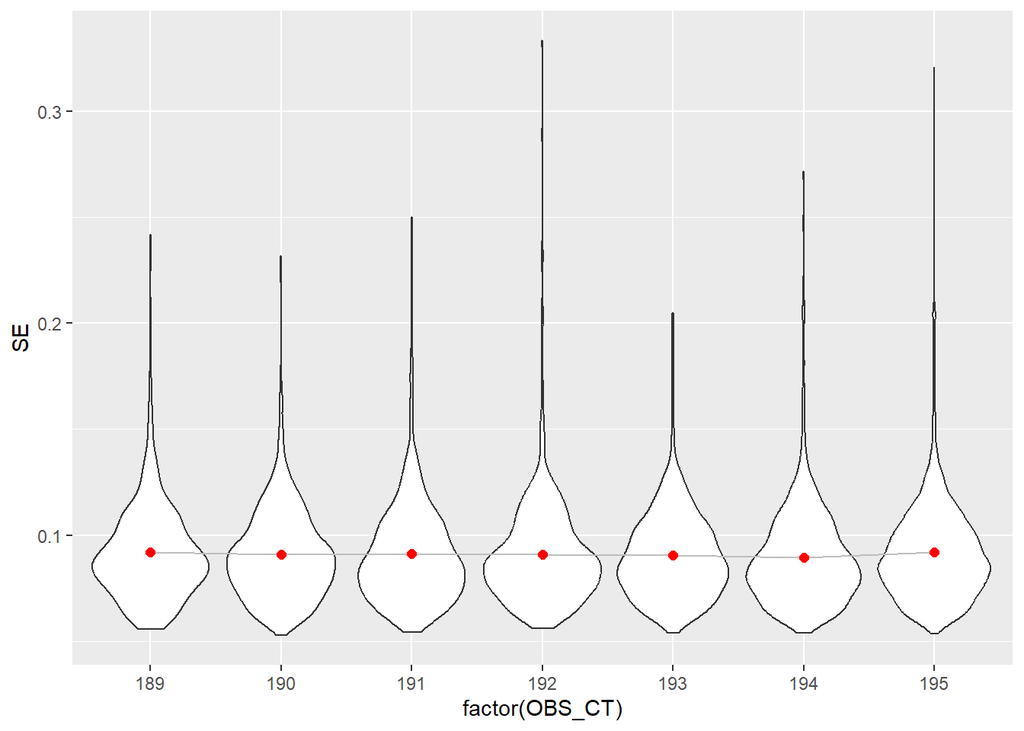

```r
ggplot(data = gwas,
       mapping = aes(x = factor(OBS_CT),
                     y = SE)) +
   geom_violin() +
   # Con "group = 1" definimos un único grupo (cualquier valor constante sirve),
   # para que una línea una todos los puntos, en lugar de generar una línea en
   # cada valor de X:
   stat_summary(geom = 'line',
                fun = 'mean',
                group = 1,
                colour = 'gray') +
   # Los puntos, en cambio, son uno para cada grupo:
   stat_summary(geom = 'point',
                fun = 'mean',
                colour = 'red',
                size = 2)
```

Otra forma de representarlo:

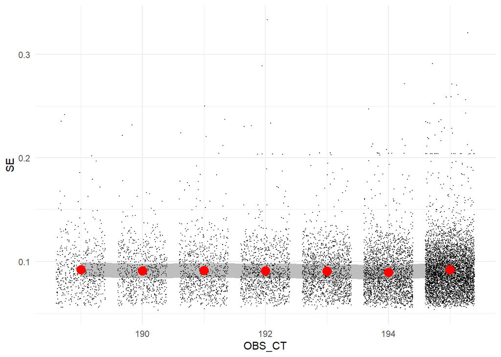

```r
ggplot(data = gwas, aes(x = OBS_CT, y = SE)) +
   stat_summary(geom = 'line', fun = 'mean', linewidth = 7, color = 'gray') +
   geom_point(position = 'jitter', size = 0.1) +
   stat_summary(geom = 'point', fun = 'mean', color = 'red', size = 4) +
   theme_minimal()
```

**NotaDesafío**

1. ¿Para qué sirve la opción `position = 'jitter'`?

Sirve para que los puntos no se queden completamente amontonados unos encima de otros en una línea recta. Al añadir el ‘jitter’, R les mete un poco de dispersión o ruido al azar hacia los lados para que podamos ver mucho mejor cuántos puntos reales hay acumulados en cada tamaño de muestra.

2. ¿Por qué en la gráfica de violines teníamos que especificar `group = 1` y en la siguiente no, al representar la línea?

En la de violines la variable X es un factor (factor(OBS_CT)), así que R trata cada tamaño de muestra como un grupo separado e independiente. Si no pones group = 1, R intenta hacer una línea dentro de cada categoría y no dibuja nada; con ese truco le obligas a conectar las medias de todos los grupos. En cambio, en la segunda gráfica X es una variable numérica continua, por lo que R ya entiende de forma natural que todos los datos forman parte de un mismo conjunto y traza la línea continua sin ayuda.

3. ¿Para qué sirve la función `factor()` al representar la gráfica de violines?

Sirve para transformar una variable numérica en una variable categórica o cualitativa. Para poder pintar un gráfico de violines, R necesita que el eje X esté dividido en categorías claras; al aplicar factor(), tratamos los 7 valores numéricos del tamaño muestral como si fuesen 7 etiquetas o grupos distintos para que se pueda dibujar un violín individual en cada uno.

4. ¿Se te ocurre alguna otra manera de combinar datos y sus estadísticos (como la media) en un mismo gráfico, sin usar `stat_summary()`? ¿Qué método te gusta más?

Se podría hacer calculando las medias por nuestra cuenta antes de hacer el gráfico. Te vas a dplyr, usas group_by() y summarise() para hacerte una tabla aparte con las medias ya calculadas. Luego, en el ggplot(), metes los puntos normales con la tabla grande y le sumas un geom_point() o un geom_line() pasándole esa nueva mini tabla en el argumento data.

# Barras

Si combinamos el alelo A1 con el OMITTED, clasificamos cada SNP en una de las 12 posibles combinaciones de dos nucleótidos diferentes. Podemos representar las frecuencias de los 12 tipos de SNPs con un gráfico de barras. Obsérvalo e intenta explicar el patrón.

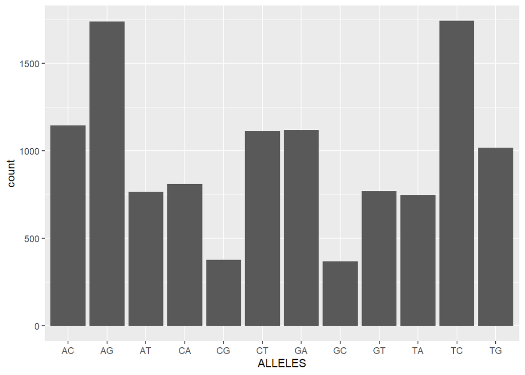

```r
gwas$ALLELES <- paste0(gwas$A1, gwas$OMITTED)
ggplot(data = gwas, mapping = aes(x = ALLELES)) + geom_bar(stat = 'count')
```

El patrón de esta gráfica se explica por la naturaleza química de las bases nitrogenadas, que se dividen en purinas (A y G) y pirimidinas (C y T), y refleja cómo ocurren las mutaciones en el genoma.

Por un lado, las barras más altas corresponden a las transiciones, que son los cambios entre bases del mismo tipo químico, es decir, de una purina a otra (de A a G) o de una pirimidina a otra (de T a C). Al mantener una estructura similar, la maquinaria celular comete estos errores con más frecuencia y el genoma los tolera mejor. Además, la gráfica muestra una simetría casi perfecta entre estos dos grupos debido a la complementariedad de las hebras del ADN: cuando ocurre una mutación de A a G en una cadena, automáticamente se genera el cambio de T a C en la cadena opuesta.

El caso más extremo se observa en las combinaciones CG y GC, que son las barras más bajas de todo el gráfico. Esto se debe a que los dinucleótidos CpG en el genoma suelen estar metilados, un estado químico que los vuelve muy inestables y propensos a sufrir desaminación, transformándose en otros nucleótidos a lo largo de la evolución. De ahí que la presencia de estas dos combinaciones sea la más reducida en la muestra.

`geom_bar()` automáticamente representa el número de observaciones de cada tipo. Este geométrico usa el estético `fill` para el color de las barras. Podemos mapear una variable categórica a `fill`. Por ejemplo, ahora que tenemos clasificados los SNPs en 12 categorías, veamos cuántos hay de cada tipo en cada cromosoma:

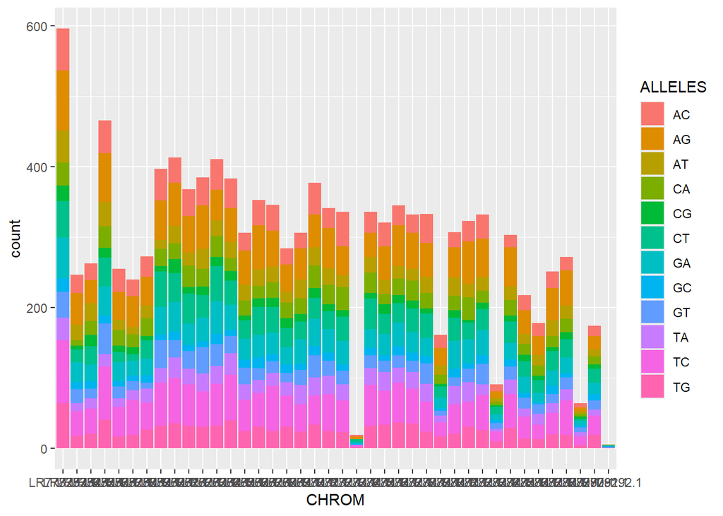

```r
ggplot(data = gwas, mapping = aes(x= CHROM, fill = ALLELES)) +
   geom_bar()
```

**NotaDesafíos**

1. Genera una nueva variable categórica en `gwas` que indique si el SNP es una transición (AG, GA, CT, TC) o una transversión (los otros) y comprueba con un diagrama de barras si las proporciones son comparables entre cromosomas.

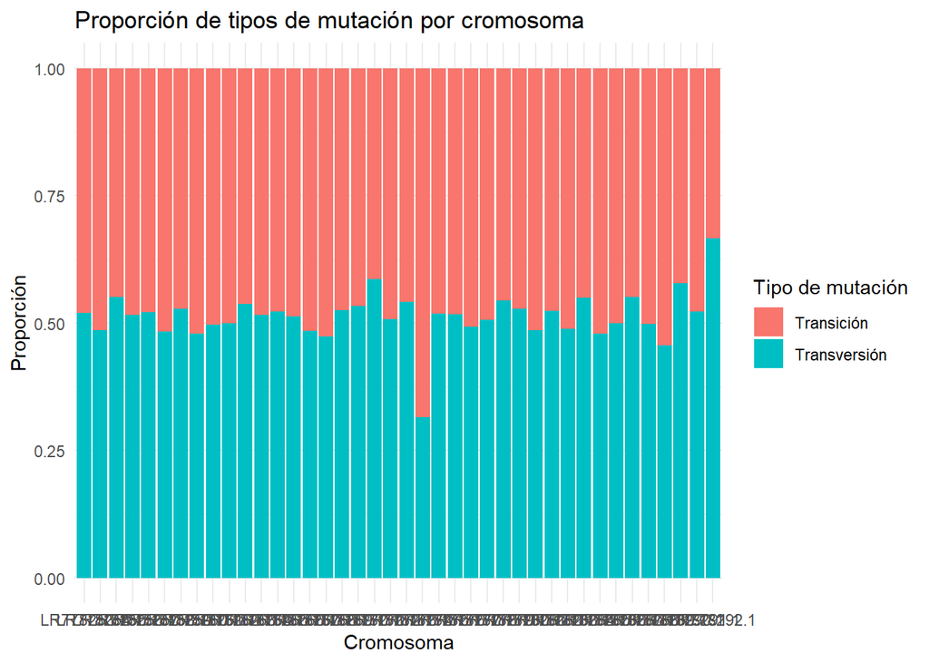

```r
gwas$mut_type <- ifelse(gwas$ALLELES %in% c("AG", "GA", "CT", "TC"),
                        "Transición", "Transversión")


ggplot(data = gwas, mapping = aes(x = factor(CHROM), fill = mut_type)) +
   geom_bar(position = "fill") +
   labs(title = "Proporción de tipos de mutación por cromosoma",
        x = "Cromosoma",
        y = "Proporción",
        fill = "Tipo de mutación") +
   theme_minimal()
```

2. Mira también si existe relación entre el tipo de mutación y la frecuencia alélica.

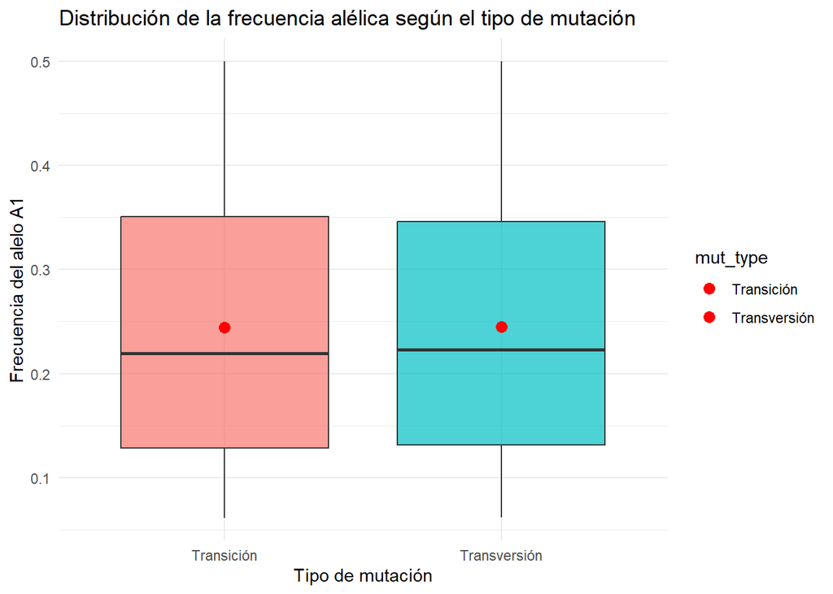

```r
ggplot(data = gwas, mapping = aes(x = mut_type, y = A1_FREQ, fill = mut_type)) +
   geom_boxplot(alpha = 0.7, show.legend = FALSE) +
   stat_summary(fun = "mean", geom = "point", color = "red", size = 3) +
   labs(title = "Distribución de la frecuencia alélica según el tipo de mutación",
        x = "Tipo de mutación",
        y = "Frecuencia del alelo A1") +
   theme_minimal()
```

La gráfica resultante muestra que los diagramas de cajas, los rangos intercuartílicos y las medias de las frecuencias (representadas por el punto rojo) son casi idénticos en ambos grupos. Esto indica que no existe una relación directa entre el tipo de mutación (transición o transversión) y la frecuencia con la que se mantienen estos alelos en los datos analizados.

# Gráficas de volcán

Las gráficas de volcán representan simultáneamente la significación de cada resultado (valor *p*) y la magnitud (y el signo) del efecto estimado. Los valores *p* se muestran en escala logarítmica y con el signo cambiado, para que los resultados más significativos destaquen como *mayores*. Podemos añadir algunas líneas que indiquen los umbrales arbitrarios que utilizamos para seleccionar los resultados creíbles, o bien añadir color a los puntos seleccionados como positivos. A la hora de decidir estos umbrales es fundamental conocer la tasa de falsos positivos esperada con cada umbral (FDR). Para ello, añadimos al marco de datos una columna con el valor *q* [^1], calculado con la función `qvalue()` del paquete `qvalue` (Storey et al. 2025).

```r
library('qvalue')
```

[output not shown]

```r
gwas$q <- qvalue(gwas$P)$qvalues
```

[output not shown]

```r
ggplot(data = gwas,
       mapping = aes(x = BETA, y = -log(P), color = q)) +
   geom_point() +
   scale_color_gradient(name = 'FDR', trans = 'log',
                        breaks = c(0.001, 0.01, 0.1),
                        low= 'red', high='gray') +
   geom_abline(intercept = -log(max(gwas[gwas$q <= 0.001, 'P'])),
               slope = 0, linewidth = 0.2, linetype = 2, color = 'black') +
   theme_minimal()
```

[output not shown]

**ERROR** Me pide una versión de R distinta para instalar el paquete qvalue. Como alternativa, he consultado otra forma de realizar la gráfica volcán sin emplear qvalue:

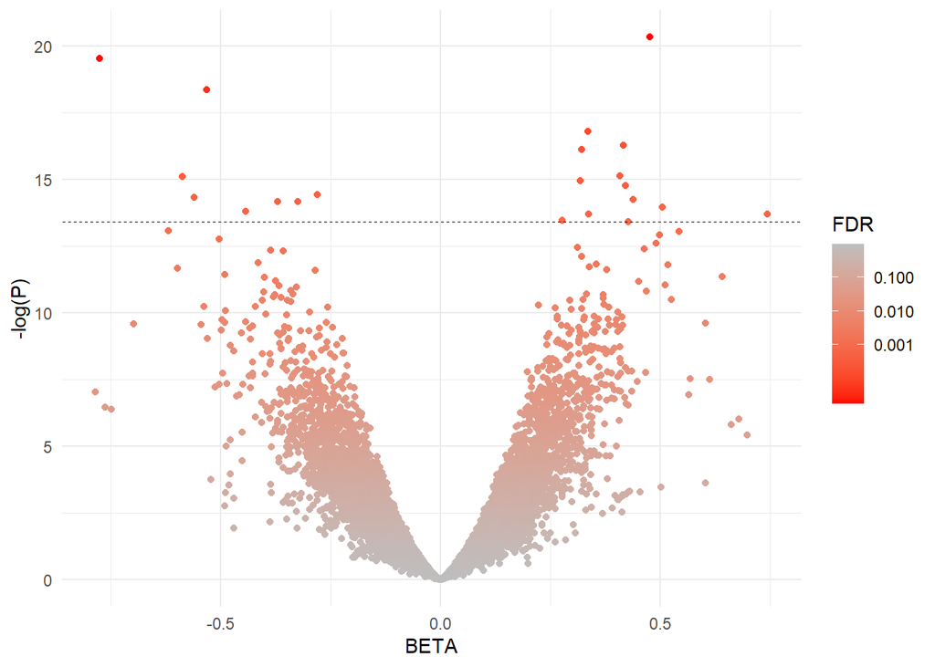

```r
# Calculamos el FDR usando la función nativa de R
gwas$q <- p.adjust(gwas$P, method = 'fdr')

# Generamos la gráfica de volcán
ggplot(data = gwas,
       mapping = aes(x = BETA, y = -log(P), color = q)) +
   geom_point() +
   scale_color_gradient(name = 'FDR', trans = 'log',
                        breaks = c(0.001, 0.01, 0.1),
                        low = 'red', high = 'gray') +
   # Ajustamos la línea con el valor máximo de P donde q es menor o igual a 0.001
   geom_abline(intercept = -log(max(gwas[gwas$q <= 0.001, 'P'])),
               slope = 0, linewidth = 0.2, linetype = 2, color = 'black') +
   theme_minimal()
```

**NotaDesafíos**

1. Genera una gráfica de volcán para cada cromosoma.

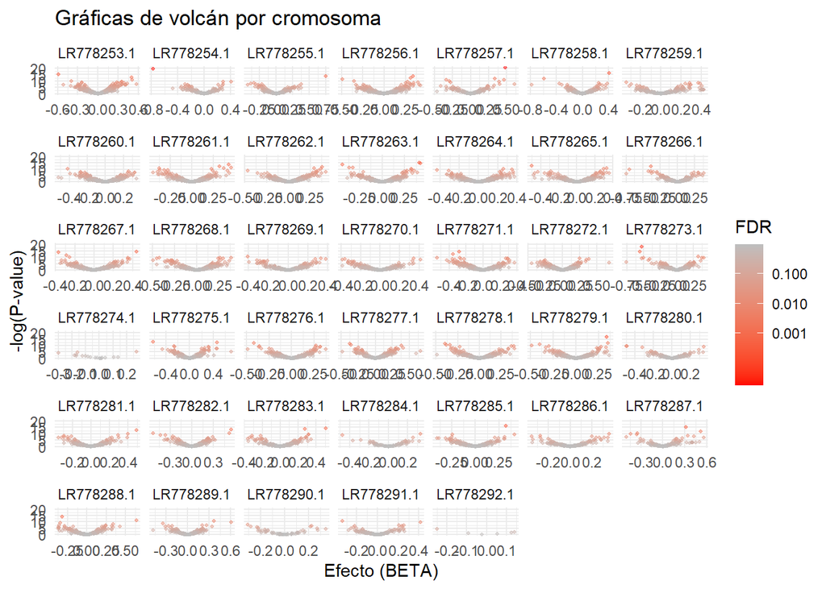

```r
gwas$q <- p.adjust(gwas$P, method = 'fdr')

ggplot(data = gwas, mapping = aes(x = BETA, y = -log(P), color = q)) +
   geom_point(alpha = 0.5, size = 0.8) +
   scale_color_gradient(name = 'FDR', trans = 'log',
                        breaks = c(0.001, 0.01, 0.1),
                        low = 'red', high = 'gray') +
   facet_wrap(~CHROM, scales = "free_x") +
   labs(title = "Gráficas de volcán por cromosoma",
        x = "Efecto (BETA)",
        y = "-log(P-value)") +
   theme_minimal()
```

Para separar la gráfica de volcán por cromosomas sin saturar la pantalla, se añade la función facet_wrap(). Al utilizar scales = “free_x”, se consigue que el eje X (que son los valores de BETA) se ajuste de forma independiente al rango de efectos de cada cromosoma, manteniendo el eje Y fijo para poder compararlos directamente entre ellos.

2. El número de SNPs cuyo genotipo está significativamente asociado al fenotipo, ¿te parece elevado o bajo?

   El número de SNPs significativos es tirando a bajo si lo comparamos con el total de variantes que se están analizando en el estudio. Al mirar las gráficas de volcán, se ve claramente que la inmensa mayoría de los puntos se quedan acumulados abajo del todo, con un valor de $-log(P)$ muy bajo, pintados de color gris. Solo unos pocos puntos consiguen subir y teñirse de rojo en la parte alta del gráfico. Esto es lo normal en este tipo de estudios genéticos (GWAS), ya que la mayor parte del genoma no tiene ninguna relación con el rasgo que estamos estudiando y solo unas pocas variantes concretas muestran una asociación real.
3. Escoge un umbral y clasifica los SNPs en “positivos” y “negativos”, y explora la proporción de positivos por cromosoma. ¿Puedes hacerlo sin añadir una columna al marco de datos?

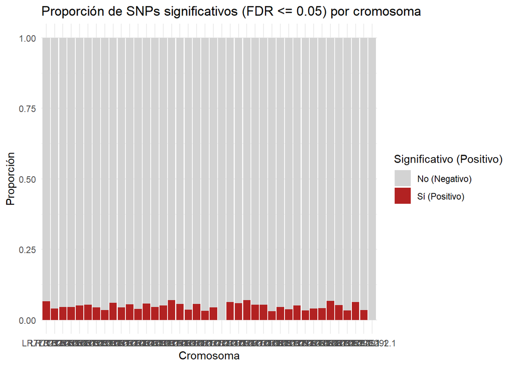

```r
ggplot(data = gwas, mapping = aes(x = factor(CHROM), fill = q <= 0.05)) +
   geom_bar(position = "fill") +
   labs(title = "Proporción de SNPs significativos (FDR <= 0.05) por cromosoma",
        x = "Cromosoma",
        y = "Proporción",
        fill = "Significativo (Positivo)") +
   scale_fill_manual(values = c("TRUE" = "firebrick", "FALSE" = "lightgray"),
                     labels = c("TRUE" = "Sí (Positivo)", "FALSE" = "No (Negativo)")) +
   theme_minimal()
```

Sí, se puede hacer directamente si se mete una condición (como q <= 0.05) dentro del argumento fill en el aes(). Al hacerlo de esta manera, R evalúa la condición lógica para cada fila sobre la marcha y divide las barras en verdaderos (TRUE) y falsos (FALSE). Si además combinas esto con position = “fill”, el gráfico transforma automáticamente los conteos en proporciones de 0 a 1 para cada cromosoma sin necesidad de tocar para nada el data frame original.